# Презентация

по лабораторной работе № 2

Зинченко А.Р

Российский университет дружбы народов, Москва, Россия

НБИбд-01-23

29 февраля 2024

# Информация

## Докладчик

# Цель работы

Изучить идеологию и применение средств контроля версий и освоить умения по работе с git.

# Задание

1. Установка программного обеспечения а. Установка git б. Установка gh
2. Базовая настройка git
3. Создайте ключи ssh
4. Создайте ключи pgp
5. Настройка github
6. Добавление PGP ключа в GitHub
7. Настройка автоматических подписей коммитов git
8. Настройка gh
9. Шаблон для рабочего пространства а. Сознание репозитория курса на основе шаблона б. Настройка каталога курса

## Выполнение лабораторной работы

Установила git с помощью команды dnf install git.

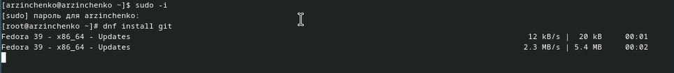

Установка git

Установила gh с помощью команды dnf install gh.

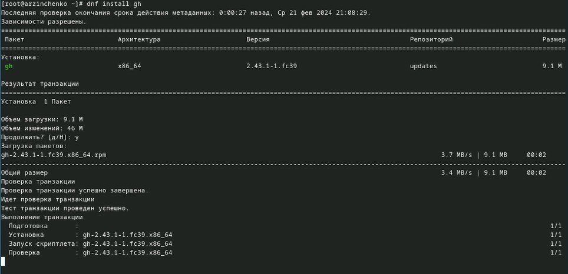

Установка gh

## Выполнение лабораторной работы

Задала имя и email своего репозитория с помощью команд git config –global user.name “Anastasiia” git config –global user.email “zinchenkoa06zinchenko@yandex.ru”.

Настроила utf-8 в выводе сообщений git с помощью команды git config –global core.quotepath false.

## Выполнение лабораторной работы

Задала имя начальной ветки с помощью команды git config –global init.defaultBranch master.

Задала параметр autocrlf с помощью команды git config –global core.autocrlf input.

## Выполнение лабораторной работы

Задала параметр safecrlf с помощью команды git config –global core.safecrlf warn.

Создала ключ ssh по алгоритму rsa с ключём размером 4096 бит с помощью команды ssh-keygen -t rsa -b 4096.

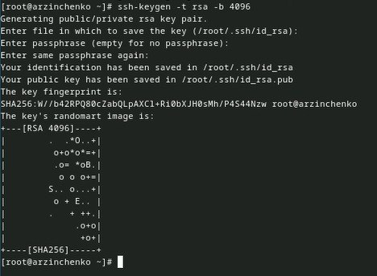

Ключ ssh по алгоритму rsa

## Выполнение лабораторной работы

Создала ключ ssh по алгоритму ed25519 с помощью команды ssh-keygen -t ed25519.

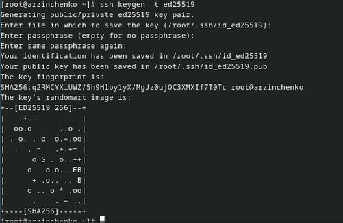

Ключ ssh по алгоритму ed25519

Сгенерировала ключ gpg с помощью команды gpg –full-generate-key.

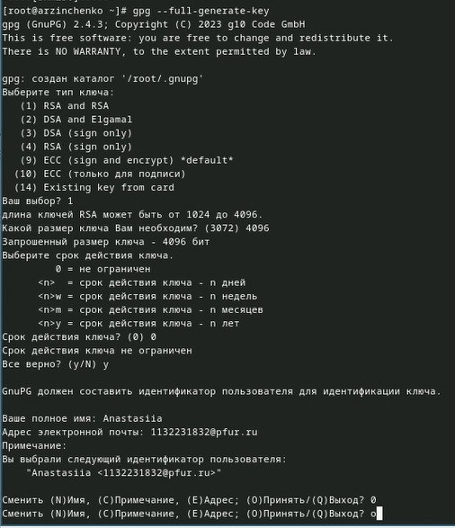

Генерация ключа

## Выполнение лабораторной работы

Из предложенных опций выбирала тип RSA and RSA; размер 4096; срок действия; имя; адрес электронной почты

У меня уже была создана учётная запись на Github и были заполнены основные данные.

[figure not shown]

Учётная запись Github

Вывела список ключей и скопировала отпечаток приватного ключа с помощью команды gpg –list-secret-keys –keyid-format LONG.

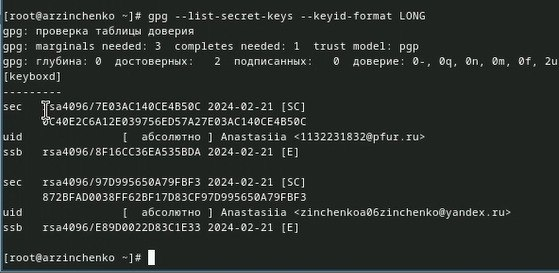

Список ключей

## Выполнение лабораторной работы

Cкопировала сгенерированный PGP ключ в буфер обмена с помощью команды gpg –armor –export | xclip -sel clip. Перешла в настройки GitHub, нажала на кнопку New GPG key и вставила полученный ключ в поле ввода.

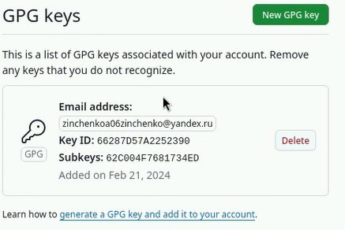

Список ключей

Используя zinchenkoa06zinchenko@yandex.ru, указала Git применять его при подписи коммитов с помощью команд git config –global user.signingkey git config –global commit.gpgsign true git config –global gpg.program $(which gpg2).

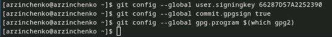

Подписи коммиттов

## Выполнение лабораторной работы

Я авторизовалась с помощью команды gh auth login.

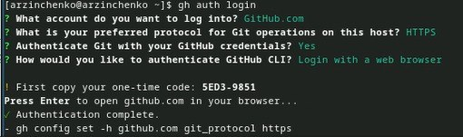

Авторизация

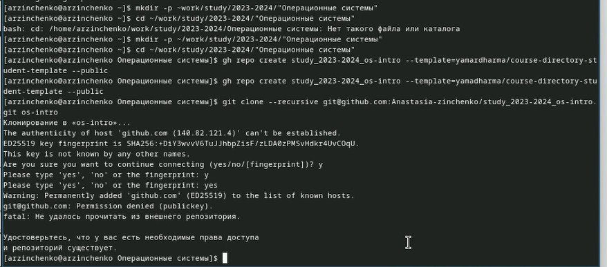

Создание репозитория

## Выполнение лабораторной работы

Удалила лишние файлы с помощью команды rm package.json.

## Выполнение лабораторной работы

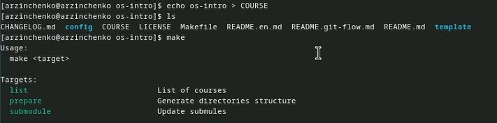

Создание каталогов

Отправила файлы на сервер с помощью команд git add . git commit -am ‘feat(main): make course structure’ git push.

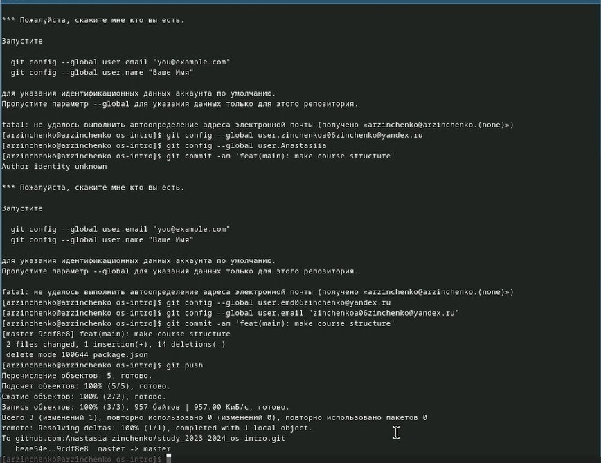

Создание каталогов

Проверка файлов на сервере.

[figure not shown]

Проверка

# Выводы

Я изучила идеологию и применение средств контроля версий и освоила умения по работе с git.